# 2_CL_Data__Data_Cleaning__generates_AEI_No_NAs

Rachel Ledig

4/20/2021

Here is the data necessary for this script:

```r
#original Siebert Data
aei <- read.csv2(
  "/Volumes/RachelExternal/Thesis/Data/SiebertData/HID_v10/Country_tenyear_ha.csv")
#import the data set with total country area, this comes from the Worldbank
countryarea <- read.csv2(
  "/Volumes/RachelExternal/Thesis/Data/LandArea/LandArea.csv")
#the ISO codes and regional data from Gapminder
iso <- read.csv2(
  "/Volumes/RachelExternal/Thesis/Thesis/Data/GAPminder_ISOcodes.csv")
#income here is 2011 usd, taken from Gapminder
income <- read.csv(
  "/Volumes/RachelExternal/Thesis/Thesis/Data/Gapminder_income_per_person_gdppercapita_ppp_inflation_adjusted.csv")
#population data also taken from Gapminder
population <- read.csv(
  "/Volumes/RachelExternal/Thesis/Thesis/Data/Gapminder_population_total.csv")
#cft taken from LPJmL output
cft <- read.csv(
  '/Volumes/RachelExternal/Thesis/Thesis/Data/cft_and_precipdata.csv')
#humidity, PET, and precipitation
hum_PET_prec <- read.csv(
  '/Volumes/RachelExternal/Thesis/Thesis/Data/hum_pet_prec.csv')
```

Lets do a short introduction to what we’re working with here.

# Target Variable

- $I$ - Irrigation Percentage - Downloaded the data from Siebert et al. (2015) data set in ha/country/timestep, then by dividing by the countries total area, the fraction of total land area that is irrigated in a given country is created. I will be working with data from 1910-2005. The first years of Siebert et al. (2015) are a bit off, and some of my data derived from LPJmL output only starts in 1901. To avoid further conflicts my study period will be 1910-2005 for the country level model.

```r
aei <- as.data.frame(aei)

#rename the cols so that I can use them as number
colnames(aei) <- c("country", "ISO", "ID", "1900", "1910","1920","1930","1940","1950","1960","1970","1980","1985","1990","1995","2000","2005")

#tidying data to long format
aei <- pivot_longer(aei,cols = 4:17, names_to = "year", values_to = "aei_ha")
aei$aei_ha <- removePunctuation(aei$aei_ha)
aei$year <- as.numeric(aei$year)
aei$aei_ha <- as.numeric(aei$aei_ha)
aei$ISO <- as.factor(aei$ISO)
aei$country <- as.factor(aei$country)

#remove 1900
aei <- subset(aei, year != "1900")

#make a new col for year count
aei$yearcount <- (aei$year - 1910)

#remove data for the total global irrigated area
globeaei <- subset(aei, country == "WORLD")
aei= aei[!aei$country == "WORLD",]

str(aei)
```

```
## tibble [3,003 × 6] (S3: tbl_df/tbl/data.frame)
##  $ country  : Factor w/ 232 levels "Afghanistan",..: 1 1 1 1 1 1 1 1 1 1 ...
##  $ ISO      : Factor w/ 232 levels "","ABW","AFG",..: 3 3 3 3 3 3 3 3 3 3 ...
##  $ ID       : int [1:3003] 2 2 2 2 2 2 2 2 2 2 ...
##  $ year     : num [1:3003] 1910 1920 1930 1940 1950 ...
##  $ aei_ha   : num [1:3003] 666667 733333 800000 1309677 1819355 ...
##  $ yearcount: num [1:3003] 0 10 20 30 40 50 60 70 75 80 ...
```

Added to this to be able to calculate the % of land irrigated per country we need the country area. This data is taken from Worldbank.

```r
#removing extra cols
countryarea <- countryarea[-c(265:270), ]
countryarea <- countryarea[, -c(1, 3:4)]

#fix the col names (in the two days since i found this little for loop I learned how to do this faster!)
for ( col in 2:ncol(countryarea)){
    colnames(countryarea)[col] <-  sub("X", "", colnames(countryarea)[col])
}
remove(col)

#making long data
countryarea <-
  countryarea %>%
  pivot_longer(!Country.Code, names_to = "year", values_to = "area_km") %>%
  rename(ISO = Country.Code)

#fixing variable types
countryarea$ISO <- as.factor(countryarea$ISO)
countryarea$year <- as.numeric(countryarea$year)
str(countryarea)
```

```
## tibble [16,104 × 3] (S3: tbl_df/tbl/data.frame)
##  $ ISO    : Factor w/ 264 levels "ABW","AFG","AGO",..: 1 1 1 1 1 1 1 1 1 1 ...
##  $ year   : num [1:16104] 1960 1961 1962 1963 1964 ...
##  $ area_km: num [1:16104] NA 180 180 180 180 180 180 180 180 180 ...
```

For some reason, the data from Worldbank on each countries area only starts in 1961. For this analysis, data back to 1910 is needed. Country area from 1961 will be substituted for backwards, with the assumption that country area doesn’t change drastically. Also here, merge the country area with the AEI df here.

```r
#combine these data sets
aei <- aei %>% merge(y = countryarea, by.x = c("ISO", "year"), all.x = TRUE)

#going to do the same thing as before so that I have area for all the other years
#assuming that political borders are the same as in the year 2005
aei <-
  aei %>%
  group_by(ISO) %>%
  fill(area_km, .direction = "up") %>%
  ungroup()

rm(countryarea)
head(aei)
```

```
## # A tibble: 6 x 7
##   ISO    year country    ID aei_ha yearcount area_km
##   <fct> <dbl> <fct>   <int>  <dbl>     <dbl>   <dbl>
## 1 ABW    1910 Aruba       1      0         0     180
## 2 ABW    1920 Aruba       1      0        10     180
## 3 ABW    1930 Aruba       1      0        20     180
## 4 ABW    1940 Aruba       1      0        30     180
## 5 ABW    1950 Aruba       1      0        40     180
## 6 ABW    1960 Aruba       1      0        50     180
```

Some countries also have no area value. I’ll go through and see if any of the countries with missing area values have non zero AEI_ha. If so, I’ll replace them, as they didn’t come through with the WorldBank data set but are online. Copying and pasting from various sources should be fine.

```r
#checking for countries with NA values in their area_km col
#looking primarily for countries that have non 0 AEI_ha
aei[is.na(aei$area_km),]
```

```
## # A tibble: 351 x 7
##    ISO    year country     ID aei_ha yearcount area_km
##    <fct> <dbl> <fct>    <int>  <dbl>     <dbl>   <dbl>
##  1 AIA    1910 Anguilla     4      0         0      NA
##  2 AIA    1920 Anguilla     4      0        10      NA
##  3 AIA    1930 Anguilla     4      0        20      NA
##  4 AIA    1940 Anguilla     4      0        30      NA
##  5 AIA    1950 Anguilla     4      0        40      NA
##  6 AIA    1960 Anguilla     4      0        50      NA
##  7 AIA    1970 Anguilla     4      0        60      NA
##  8 AIA    1980 Anguilla     4      0        70      NA
##  9 AIA    1985 Anguilla     4      0        75      NA
## 10 AIA    1990 Anguilla     4      0        80      NA
## # … with 341 more rows
```

```r
#fixing counties with no area
aei$area_km[which(aei$ISO == "GUF")] <- 83534 #French Guiana from Britannica
aei$area_km[which(aei$ISO == "GLP")] <- 1630 #Guadeloupe from Britannica
aei$area_km[which(aei$ISO == "MTQ")] <- 1128 # Martinique from Britannica
aei$area_km[which(aei$ISO == "REU")] <- 2512 #Reunion from Britannica
aei$area_km[which(aei$ISO == "SMK")] <- 13812 + 10905 + 77589 #Montenegro + Kosovo + Serbia from Britannica
aei$area_km[which(aei$ISO == "TWN")] <- 35980 #Taiwan from CIA.gov
aei$area_km[which(aei$ISO == "SDN")] <- 1882000 #Sudan from UNDP
```

Now, transform the AEI_ha to $km^2$ and divide to get the % of total country area that is equipped for irrigation. There are still some countries that have 0 AEI_ha and no area_km value. I think I will assign the irrfrac/perc 0 to those countries, but lets wait a little while to do that, most are islands.

```r
aei <- aei %>% mutate(irrperc = ((aei_ha/100)/area_km)*100, irrfrac = ((aei_ha/100)/area_km))
```

Here is a quick histogram of the target variable. A lot of 0s.

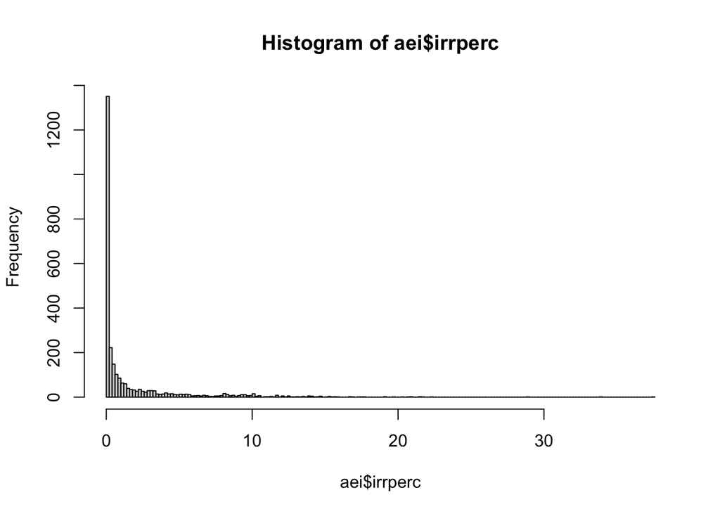

```r
hist(aei$irrperc, breaks = 200)
```

# Chosen Predictor Variables

According to the FAO (Walker 1989), the choice of which irrigation, and by proxy whether to irrigate or not, comes from six factors. The predictor that will be used for this analysis are listed below:

- Economic
  - $M_c$ - GDP per Capita - Each country’s GDP per Capita from Gapminder, which collects data from the UN and the Maddison project. This variable will be logged because as stated in *Statistical Rethinking* (McElreath 2020) McElreath states (pg. 239), “We use the logarithm of it, because the logarithm of GDP is the *magnitude* of GDP. Since wealth generates wealth, it tends to be exponentially related to anything that increases it”
- Topographical
  - $Ru_c$ - Represented here using the “rugged” data set from rethinking, in which a coeff of ruggedness for each country was assigned. This data was taken from Riley, Degloria, and Elliot (1999)
- Soil Type
  - This will not be included in this analysis. Although, it could be useful there is no good way to quantify soil type on a country level basis. This will be included in the grid cell model, as regions can be easily integrated with the grid cell structure.
- Water Supply
  - $R_c$ - Total Precipitation - Translated output from LPJmL. Summed across two dimensions: month and country. In $m^3$/country/year
  - $H_c$ - Mean/Median Humidity - Translated output from LPJmL. Calculated from $Precip/PET$ for each grid cell then averaged (or median) for each country and year.
  - $E_c$ - Mean/Median Potential Evapotranspiration - Translated output from LPJmL. Average and median were taken for each country and year.
- Crop Type
  - Fraction of each crop grown per country - Translated output from LPJmL. Individual crop fraction per grid cell multiplied by respective grid cell area, summed on a country level giving ha of each crop grown per country. This was then divided by total area of the country to achieve the % area occupied by a certain crop per country. Still working out how to work with this predictor.
- Social Influences
  - $P_c$ - Total Population - Each country’s total population on a yearly basis. Taken from Gapminder. Again, this will be logged, due to the same argument for GDP, and centered.

All variables will be scaled or centered.

First, the ISO codes and Regions to be able to hold some structure.

```r
iso <- iso[, -c(2,7,10,12,13)] #removing extra info

#renaming some cols
iso <-
  iso %>%
  rename(ISO = GEO, country = name)

#fixing the variable types
iso$ISO <- as.factor(iso$ISO)
iso$country <- as.factor(iso$country)
iso$four_regions <- as.factor(iso$four_regions)
iso$eight_regions <- as.factor(iso$eight_regions)
iso$six_regions <- as.factor(iso$six_regions)
iso$six_regions <- as.factor(iso$six_regions)
iso$World.bank.region <- as.factor(iso$World.bank.region)
str(iso)
```

```
## 'data.frame':    197 obs. of  8 variables:
##  $ ISO              : Factor w/ 197 levels "AFG","AGO","ALB",..: 1 3 50 4 2 8 6 7 9 10 ...
##  $ country          : Factor w/ 197 levels "Afghanistan",..: 1 2 3 4 5 6 7 8 9 10 ...
##  $ four_regions     : Factor w/ 4 levels "africa","americas",..: 3 4 1 4 1 2 2 4 3 4 ...
##  $ eight_regions    : Factor w/ 8 levels "africa_north",..: 5 7 1 8 2 3 4 7 6 8 ...
##  $ six_regions      : Factor w/ 6 levels "america","east_asia_pacific",..: 5 3 4 3 6 1 1 3 2 3 ...
##  $ Latitude         : num  33 41 28 42.5 -12.5 ...
##  $ Longitude        : num  66 20 3 1.52 18.5 ...
##  $ World.bank.region: Factor w/ 8 levels "","East Asia & Pacific",..: 7 3 5 3 8 4 4 3 2 3 ...
```

```r
#past me helping future me
#fixing Macedonia, FYR to North Macedonia
iso$country <- as.character(iso$country)
iso[iso == "Macedonia, FYR"] <- "North Macedonia"
iso$country <- as.factor(iso$country)
```

Cool, we have multiple regions here that we could use in the future for some multilevel business. Also, latitude and longitude is here, which we can also try later. Obviously these lat and lon measurements will mean nothing for a country like China or the USA, but they are nice to have.

## Income

Income data is coming from Gapminder, as they have put real effort in to filling all the gaps in income and population for the last 150 years. Income is in terms of the 2011 USD and is inflation adjusted.

```r
income <- income[, c(1, 102:207)] #removing extra years

#making long data
income <-
  income %>%
  pivot_longer(!country, names_to = "year", values_to = "income")

#still have the xs there
income$year <- str_remove_all(income$year, "[X]")
#transformation of the variable types
income$year <- as.numeric(income$year)
income$country <- as.factor(income$country)

#a summary
summary(income)
```

```
##                 country           year          income
##  Afghanistan        :  106   Min.   :1900   Min.   :   312
##  Albania            :  106   1st Qu.:1926   1st Qu.:  1290
##  Algeria            :  106   Median :1952   Median :  2650
##  Andorra            :  106   Mean   :1952   Mean   :  6572
##  Angola             :  106   3rd Qu.:1979   3rd Qu.:  6500
##  Antigua and Barbuda:  106   Max.   :2005   Max.   :179000
##  (Other)            :19822
```

```r
#past me helping future me again
#fixing Eswatini to Swaziland (even though Eswatini is the correct name)
income$country <- as.character(income$country)
income[income == "Eswatini"] <- "Swaziland"
income$country <- as.factor(income$country)
```

## Population

Population data is also taken from Gapminder.

```r
#removing extra years
population <- population[, c(1, 102:207)]
#making longer data
population <-
  population %>%
  pivot_longer(!country, names_to = "year", values_to = "population")

#removing the Xs from the year strings
population$year <- str_remove_all(population$year, "[X]")

#fixing variable types
population$country <- as.factor(population$country)
population$year <- as.numeric(population$year)

summary(population)
```

```
##                 country           year        population
##  Afghanistan        :  106   Min.   :1900   Min.   :6.450e+02
##  Albania            :  106   1st Qu.:1926   1st Qu.:4.732e+05
##  Algeria            :  106   Median :1952   Median :2.810e+06
##  Andorra            :  106   Mean   :1952   Mean   :1.667e+07
##  Angola             :  106   3rd Qu.:1979   3rd Qu.:8.750e+06
##  Antigua and Barbuda:  106   Max.   :2005   Max.   :1.330e+09
##  (Other)            :20034
```

```r
#annnd again...
#fixing Eswatini to Swaziland (even though Eswatini is the correct name)
population$country <- as.character(population$country)
population[population == "Eswatini"] <- "Swaziland"
population$country <- as.factor(population$country)
```

So some issues arise here with the fact that we have different country data for each dataframe. Sometimes the names are capitalized, other times there are spaces instead of underscores. By using `anti_join()` I can see what won’t be joined. Also this goes both ways, `anti_join()` returns rows of x that do not have a match in y.

```r
isopop <- anti_join(iso, population, by = "country")
summary(isopop)
```

```
##       ISO                country    four_regions            eight_regions
##  HKG    :1   Hong Kong, China:1   africa  :0     east_asia_pacific :2
##  TWN    :1   Taiwan          :1   americas:0     africa_north      :0
##  AFG    :0   Afghanistan     :0   asia    :2     africa_sub_saharan:0
##  AGO    :0   Albania         :0   europe  :0     america_north     :0
##  ALB    :0   Algeria         :0                  america_south     :0
##  AND    :0   Andorra         :0                  asia_west         :0
##  (Other):0   (Other)         :0                  (Other)           :0
##                    six_regions    Latitude       Longitude
##  america                 :0    Min.   :22.29   Min.   :114.2
##  east_asia_pacific       :2    1st Qu.:22.71   1st Qu.:115.9
##  europe_central_asia     :0    Median :23.14   Median :117.6
##  middle_east_north_africa:0    Mean   :23.14   Mean   :117.6
##  south_asia              :0    3rd Qu.:23.57   3rd Qu.:119.3
##  sub_saharan_africa      :0    Max.   :24.00   Max.   :121.0
##
##                   World.bank.region
##  East Asia & Pacific       :2
##                            :0
##  Europe & Central Asia     :0
##  Latin America & Caribbean :0
##  Middle East & North Africa:0
##  North America             :0
##  (Other)                   :0
```

```r
popiso <- anti_join(population, iso, by = "country")
summary(popiso)
```

```
##                 country       year       population
##  Afghanistan        :0   Min.   : NA   Min.   : NA
##  Albania            :0   1st Qu.: NA   1st Qu.: NA
##  Algeria            :0   Median : NA   Median : NA
##  Andorra            :0   Mean   :NaN   Mean   :NaN
##  Angola             :0   3rd Qu.: NA   3rd Qu.: NA
##  Antigua and Barbuda:0   Max.   : NA   Max.   : NA
##  (Other)            :0
```

Went back up and solved the issue of North Macedonia and Swaziland. There are still issues with Hong Kong and Taiwan as they are part of China. ISO has data for Hong Kong and Taiwan that population does not have. I wont include them in the HTML but they are in the code.

Alright, so I will left join ISO and population then again with income? Not sure that this will solve my problem, but lets try it.

```r
#remove all these rando tables
rm(popinc, inciso, incpop, popiso, isoinc, isopop)

#
iso <- left_join(iso, population, by = "country")
iso <- left_join(iso, income, by = c("country", "year"))

# alright 197 countries! whoop!
summary(iso)
```

```
##       ISO                       country        four_regions
##  AFG    :  106   Afghanistan        :  106   africa  :5724
##  AGO    :  106   Albania            :  106   americas:3710
##  ALB    :  106   Algeria            :  106   asia    :6044
##  AND    :  106   Andorra            :  106   europe  :5194
##  ARE    :  106   Angola             :  106
##  ARG    :  106   Antigua and Barbuda:  106
##  (Other):20036   (Other)            :20036
##             eight_regions                    six_regions      Latitude
##  africa_sub_saharan:5088   america                 :3710   Min.   :-42.00
##  east_asia_pacific :3182   east_asia_pacific       :3182   1st Qu.:  4.00
##  asia_west         :2862   europe_central_asia     :5724   Median : 17.33
##  europe_west       :2650   middle_east_north_africa:2120   Mean   : 19.11
##  europe_east       :2544   south_asia              : 848   3rd Qu.: 40.00
##  america_north     :2438   sub_saharan_africa      :5088   Max.   : 65.00
##  (Other)           :1908
##    Longitude                        World.bank.region      year
##  Min.   :-175.00   Europe & Central Asia     :5512    Min.   :1900
##  1st Qu.:  -6.00   Sub-Saharan Africa        :5088    1st Qu.:1926
##  Median :  21.00   Latin America & Caribbean :3498    Median :1952
##  Mean   :  21.99   East Asia & Pacific       :3182    Mean   :1952
##  3rd Qu.:  50.55   Middle East & North Africa:2226    3rd Qu.:1979
##  Max.   : 179.14   South Asia                : 848    Max.   :2005
##                    (Other)                   : 318    NA's   :2
##    population            income
##  Min.   :6.450e+02   Min.   :   312
##  1st Qu.:4.732e+05   1st Qu.:  1290
##  Median :2.810e+06   Median :  2650
##  Mean   :1.667e+07   Mean   :  6572
##  3rd Qu.:8.750e+06   3rd Qu.:  6500
##  Max.   :1.330e+09   Max.   :179000
##  NA's   :2           NA's   :214
```

```r
rm(income, population)
```

Now, join ISO to AEI with a merge (cause in this case the dynamics of merge are clearer for me). Hoping to preserve all data!

```r
aei <- merge(aei, iso, by = c("ISO","country", "year"), all.x = TRUE)
rm(iso)
summary(aei)
```

```
##       ISO                 country          year            ID
##  ABW    :  13   Afghanistan   :  13   Min.   :1910   Min.   :  1.0
##  AFG    :  13   Albania       :  13   1st Qu.:1940   1st Qu.: 62.0
##  AGO    :  13   Algeria       :  13   Median :1970   Median :125.0
##  AIA    :  13   American Samoa:  13   Mean   :1964   Mean   :125.5
##  ALB    :  13   Andorra       :  13   3rd Qu.:1990   3rd Qu.:187.0
##  AND    :  13   Angola        :  13   Max.   :2005   Max.   :400.0
##  (Other):2925   (Other)       :2925
##      aei_ha           yearcount        area_km            irrperc
##  Min.   :       0   Min.   : 0.00   Min.   :       2   Min.   : 0.00000
##  1st Qu.:       0   1st Qu.:30.00   1st Qu.:   11610   1st Qu.: 0.00586
##  Median :   12852   Median :60.00   Median :   96460   Median : 0.21376
##  Mean   :  804385   Mean   :54.23   Mean   :  612914   Mean   : 1.67096
##  3rd Qu.:  200700   3rd Qu.:80.00   3rd Qu.:  452860   3rd Qu.: 1.53916
##  Max.   :64646000   Max.   :95.00   Max.   :16389950   Max.   :37.41152
##                                     NA's   :260        NA's   :260
##     irrfrac          four_regions            eight_regions
##  Min.   :0.00000   africa  :650   africa_sub_saharan:572
##  1st Qu.:0.00006   americas:455   east_asia_pacific :351
##  Median :0.00214   asia    :676   asia_west         :325
##  Mean   :0.01671   europe  :572   europe_west       :312
##  3rd Qu.:0.01539   NA's    :650   america_north     :299
##  Max.   :0.37412                  (Other)           :494
##  NA's   :260                      NA's              :650
##                    six_regions     Latitude        Longitude
##  america                 :455   Min.   :-42.00   Min.   :-175.00
##  east_asia_pacific       :351   1st Qu.:  4.00   1st Qu.:  -9.50
##  europe_central_asia     :624   Median : 17.05   Median :  20.00
##  middle_east_north_africa:247   Mean   : 18.81   Mean   :  20.06
##  south_asia              :104   3rd Qu.: 39.75   3rd Qu.:  48.00
##  sub_saharan_africa      :572   Max.   : 65.00   Max.   : 179.14
##  NA's                    :650   NA's   :650      NA's   :650
##                   World.bank.region   population            income
##  Europe & Central Asia     :611     Min.   :1.970e+03   Min.   :   312
##  Sub-Saharan Africa        :572     1st Qu.:6.120e+05   1st Qu.:  1510
##  Latin America & Caribbean :429     Median :3.570e+06   Median :  3345
##  East Asia & Pacific       :351     Mean   :2.102e+07   Mean   :  8686
##  Middle East & North Africa:260     3rd Qu.:1.100e+07   3rd Qu.:  9155
##  (Other)                   :130     Max.   :1.330e+09   Max.   :179000
##  NA's                      :650     NA's   :650         NA's   :663
```

```r
str(aei)
```

```
## 'data.frame':    3003 obs. of  17 variables:
##  $ ISO              : Factor w/ 232 levels "","ABW","AFG",..: 2 2 2 2 2 2 2 2 2 2 ...
##  $ country          : Factor w/ 232 levels "Afghanistan",..: 12 12 12 12 12 12 12 12 12 12 ...
##  $ year             : num  1910 1920 1930 1940 1950 ...
##  $ ID               : int  1 1 1 1 1 1 1 1 1 1 ...
##  $ aei_ha           : num  0 0 0 0 0 0 0 0 0 0 ...
##  $ yearcount        : num  0 10 20 30 40 50 60 70 75 80 ...
##  $ area_km          : num  180 180 180 180 180 180 180 180 180 180 ...
##  $ irrperc          : num  0 0 0 0 0 0 0 0 0 0 ...
##  $ irrfrac          : num  0 0 0 0 0 0 0 0 0 0 ...
##  $ four_regions     : Factor w/ 4 levels "africa","americas",..: NA NA NA NA NA NA NA NA NA NA ...
##  $ eight_regions    : Factor w/ 8 levels "africa_north",..: NA NA NA NA NA NA NA NA NA NA ...
##  $ six_regions      : Factor w/ 6 levels "america","east_asia_pacific",..: NA NA NA NA NA NA NA NA NA NA ...
##  $ Latitude         : num  NA NA NA NA NA NA NA NA NA NA ...
##  $ Longitude        : num  NA NA NA NA NA NA NA NA NA NA ...
##  $ World.bank.region: Factor w/ 8 levels "","East Asia & Pacific",..: NA NA NA NA NA NA NA NA NA NA ...
##  $ population       : int  NA NA NA NA NA NA NA NA NA NA ...
##  $ income           : int  NA NA NA NA NA NA NA NA NA NA ...
```

Solved the issue, 232 factors for both countries and ISO, meaning that we have been using the original AEI file from Siebert as the main data frame to join to. Good. This is the data that needs to be maintained, NAs can pop up in other cols but not irrigated area.

But I still would like total GDP for later so lets transform using population.

```r
aei$income <- as.numeric(aei$income)
aei$population <- as.numeric(aei$population)
#mutating for total GDP and log GDP
aei <-
  aei %>%
  mutate(GDPtot = income*population)

str(aei)
```

```
## 'data.frame':    3003 obs. of  18 variables:
##  $ ISO              : Factor w/ 232 levels "","ABW","AFG",..: 2 2 2 2 2 2 2 2 2 2 ...
##  $ country          : Factor w/ 232 levels "Afghanistan",..: 12 12 12 12 12 12 12 12 12 12 ...
##  $ year             : num  1910 1920 1930 1940 1950 ...
##  $ ID               : int  1 1 1 1 1 1 1 1 1 1 ...
##  $ aei_ha           : num  0 0 0 0 0 0 0 0 0 0 ...
##  $ yearcount        : num  0 10 20 30 40 50 60 70 75 80 ...
##  $ area_km          : num  180 180 180 180 180 180 180 180 180 180 ...
##  $ irrperc          : num  0 0 0 0 0 0 0 0 0 0 ...
##  $ irrfrac          : num  0 0 0 0 0 0 0 0 0 0 ...
##  $ four_regions     : Factor w/ 4 levels "africa","americas",..: NA NA NA NA NA NA NA NA NA NA ...
##  $ eight_regions    : Factor w/ 8 levels "africa_north",..: NA NA NA NA NA NA NA NA NA NA ...
##  $ six_regions      : Factor w/ 6 levels "america","east_asia_pacific",..: NA NA NA NA NA NA NA NA NA NA ...
##  $ Latitude         : num  NA NA NA NA NA NA NA NA NA NA ...
##  $ Longitude        : num  NA NA NA NA NA NA NA NA NA NA ...
##  $ World.bank.region: Factor w/ 8 levels "","East Asia & Pacific",..: NA NA NA NA NA NA NA NA NA NA ...
##  $ population       : num  NA NA NA NA NA NA NA NA NA NA ...
##  $ income           : num  NA NA NA NA NA NA NA NA NA NA ...
##  $ GDPtot           : num  NA NA NA NA NA NA NA NA NA NA ...
```

```r
summary(aei)
```

```
##       ISO                 country          year            ID
##  ABW    :  13   Afghanistan   :  13   Min.   :1910   Min.   :  1.0
##  AFG    :  13   Albania       :  13   1st Qu.:1940   1st Qu.: 62.0
##  AGO    :  13   Algeria       :  13   Median :1970   Median :125.0
##  AIA    :  13   American Samoa:  13   Mean   :1964   Mean   :125.5
##  ALB    :  13   Andorra       :  13   3rd Qu.:1990   3rd Qu.:187.0
##  AND    :  13   Angola        :  13   Max.   :2005   Max.   :400.0
##  (Other):2925   (Other)       :2925
##      aei_ha           yearcount        area_km            irrperc
##  Min.   :       0   Min.   : 0.00   Min.   :       2   Min.   : 0.00000
##  1st Qu.:       0   1st Qu.:30.00   1st Qu.:   11610   1st Qu.: 0.00586
##  Median :   12852   Median :60.00   Median :   96460   Median : 0.21376
##  Mean   :  804385   Mean   :54.23   Mean   :  612914   Mean   : 1.67096
##  3rd Qu.:  200700   3rd Qu.:80.00   3rd Qu.:  452860   3rd Qu.: 1.53916
##  Max.   :64646000   Max.   :95.00   Max.   :16389950   Max.   :37.41152
##                                     NA's   :260        NA's   :260
##     irrfrac          four_regions            eight_regions
##  Min.   :0.00000   africa  :650   africa_sub_saharan:572
##  1st Qu.:0.00006   americas:455   east_asia_pacific :351
##  Median :0.00214   asia    :676   asia_west         :325
##  Mean   :0.01671   europe  :572   europe_west       :312
##  3rd Qu.:0.01539   NA's    :650   america_north     :299
##  Max.   :0.37412                  (Other)           :494
##  NA's   :260                      NA's              :650
##                    six_regions     Latitude        Longitude
##  america                 :455   Min.   :-42.00   Min.   :-175.00
##  east_asia_pacific       :351   1st Qu.:  4.00   1st Qu.:  -9.50
##  europe_central_asia     :624   Median : 17.05   Median :  20.00
##  middle_east_north_africa:247   Mean   : 18.81   Mean   :  20.06
##  south_asia              :104   3rd Qu.: 39.75   3rd Qu.:  48.00
##  sub_saharan_africa      :572   Max.   : 65.00   Max.   : 179.14
##  NA's                    :650   NA's   :650      NA's   :650
##                   World.bank.region   population            income
##  Europe & Central Asia     :611     Min.   :1.970e+03   Min.   :   312
##  Sub-Saharan Africa        :572     1st Qu.:6.120e+05   1st Qu.:  1510
##  Latin America & Caribbean :429     Median :3.570e+06   Median :  3345
##  East Asia & Pacific       :351     Mean   :2.102e+07   Mean   :  8686
##  Middle East & North Africa:260     3rd Qu.:1.100e+07   3rd Qu.:  9155
##  (Other)                   :130     Max.   :1.330e+09   Max.   :179000
##  NA's                      :650     NA's   :650         NA's   :663
##      GDPtot
##  Min.   :1.688e+06
##  1st Qu.:1.651e+09
##  Median :1.197e+10
##  Mean   :1.637e+11
##  3rd Qu.:6.309e+10
##  Max.   :1.460e+13
##  NA's   :663
```

### Dealing with Some Issues

There are a lot of countries that have no data for the regions, but have non zero irrperc/frac which I will use in further analysis, so we need to replace the regions.

```r
#view which countries don't have regions but have non zero irrprec
na_regions <- aei[is.na(aei$four_regions),]

#Aruba
aei <- aei %>%
  mutate(four_regions = replace(four_regions, ISO == 'ABW', 'americas'),
         six_regions = replace(six_regions, ISO == 'ABW', 'america'),
         eight_regions = replace(eight_regions, ISO == 'ABW', 'america_north')) %>%
#american samoa
  mutate(four_regions = replace(four_regions,ISO == 'ASM', 'asia'),
         six_regions = replace(six_regions,ISO == 'ASM', 'east_asia_pacific'),
         eight_regions = replace(eight_regions,ISO == 'ASM', 'east_asia_pacific')) %>%
#bermuda
  mutate(four_regions = replace(four_regions,ISO == 'BMU', 'americas'),
         six_regions = replace(six_regions,ISO == 'BMU', 'america'),
         eight_regions = replace(eight_regions,ISO == 'BMU', 'america_north')) %>%
#cote d'ivoire
  mutate(four_regions = replace(four_regions,ISO == 'CIV', 'africa'),
         six_regions = replace(six_regions,ISO == 'CIV', 'sub_saharan_africa'),
         eight_regions = replace(eight_regions,ISO == 'CIV', 'africa_sub_saharan')) %>%
#democratic republic of congo
  mutate(four_regions = replace(four_regions,ISO == 'COD', 'africa'),
         six_regions = replace(six_regions,ISO == 'COD', 'sub_saharan_africa'),
         eight_regions = replace(eight_regions,ISO == 'COD', 'africa_sub_saharan')) %>%
#republic of congo
  mutate(four_regions = replace(four_regions,ISO == 'COG', 'africa'),
         six_regions = replace(six_regions,ISO == 'COG', 'sub_saharan_africa'),
         eight_regions = replace(eight_regions,ISO == 'COG', 'africa_sub_saharan')) %>%
#cayman islands
  mutate(four_regions = replace(four_regions,ISO == 'CYM', 'americas'),
         six_regions = replace(six_regions,ISO == 'CYM', 'america'),
         eight_regions = replace(eight_regions,ISO == 'CYM', 'america_north')) %>%
#Faroe islands
  mutate(four_regions = replace(four_regions,ISO == 'FRO', 'europe'),
         six_regions = replace(six_regions,ISO == 'FRO', 'europe_central_asia'),
         eight_regions = replace(eight_regions,ISO == 'FRO', 'europe_west')) %>%
#micronesia
  mutate(four_regions = replace(four_regions,ISO == 'FSM', 'asia'),
         six_regions = replace(six_regions,ISO == 'FSM', 'east_asia_pacific'),
         eight_regions = replace(eight_regions,ISO == 'FSM', 'east_asia_pacific')) %>%
#gibraltar
  mutate(four_regions = replace(four_regions,ISO == 'GIB', 'europe'),
         six_regions = replace(six_regions,ISO == 'GIB', 'europe_central_asia'),
         eight_regions = replace(eight_regions,ISO == 'GIB', 'europe_west')) %>%
#Guadeloupe
  mutate(four_regions = replace(four_regions,ISO == 'GLP', 'americas'),
         six_regions = replace(six_regions,ISO == 'GLP', 'america'),
         eight_regions = replace(eight_regions,ISO == 'GLP', 'america_north')) %>%
#greenland
  mutate(four_regions = replace(four_regions,ISO == 'GRL', 'europe'),
         six_regions = replace(six_regions,ISO == 'GRL', 'europe_central_asia'),
         eight_regions = replace(eight_regions,ISO == 'GRL', 'europe_west')) %>%
#french Guiana
  mutate(four_regions = replace(four_regions,ISO == 'GUF', 'americas'),
         six_regions = replace(six_regions,ISO == 'GUF', 'america'),
         eight_regions = replace(eight_regions,ISO == 'GUF', 'america_south')) %>%
#guam
  mutate(four_regions = replace(four_regions,ISO == 'GUM', 'asia'),
         six_regions = replace(six_regions,ISO == 'GUM', 'east_asia_pacific'),
         eight_regions = replace(eight_regions,ISO == 'GUM', 'east_asia_pacific')) %>%
#Kyrgyzstan
  mutate(four_regions = replace(four_regions,ISO == 'KGZ', 'asia'),
         six_regions = replace(six_regions,ISO == 'KGZ', 'europe_central_asia'),
         eight_regions = replace(eight_regions,ISO == 'KGZ', 'asia_west')) %>%
#laos
  mutate(four_regions = replace(four_regions,ISO == 'LAO', 'asia'),
         six_regions = replace(six_regions,ISO == 'LAO', 'east_asia_pacific'),
         eight_regions = replace(eight_regions,ISO == 'LAO', 'east_asia_pacific')) %>%
#Macedonia
  mutate(four_regions = replace(four_regions,ISO == 'MKD', 'europe'),
         six_regions = replace(six_regions,ISO == 'MKD', 'europe_central_asia'),
         eight_regions = replace(eight_regions,ISO == 'MKD', 'europe_east')) %>%
#Martinique
  mutate(four_regions = replace(four_regions,ISO == 'MTQ', 'americas'),
         six_regions = replace(six_regions,ISO == 'MTQ', 'america'),
         eight_regions = replace(eight_regions,ISO == 'MTQ', 'america_north')) %>%
#new caledonia
  mutate(four_regions = replace(four_regions,ISO == 'NCL', 'asia'),
         six_regions = replace(six_regions,ISO == 'NCL', 'east_asia_pacific'),
         eight_regions = replace(eight_regions,ISO == 'NCL', 'east_asia_pacific')) %>%
#puerto rico
 mutate(four_regions = replace(four_regions,ISO == 'PRI', 'americas'),
         six_regions = replace(six_regions,ISO == 'PRI', 'america'),
         eight_regions = replace(eight_regions,ISO == 'PRI', 'america_north')) %>%
#Palestine (West Bank + Gaza strip)
 mutate(four_regions = replace(four_regions,ISO == 'PSE', 'asia'),
         six_regions = replace(six_regions,ISO == 'PSE', 'middle_east_north_africa'),
         eight_regions = replace(eight_regions,ISO == 'PSE', 'asia_west')) %>%
#french Polynesia
  mutate(four_regions = replace(four_regions,ISO == 'PYF', 'asia'),
         six_regions = replace(six_regions,ISO == 'PYF', 'east_asia_pacific'),
         eight_regions = replace(eight_regions,ISO == 'PYF', 'east_asia_pacific')) %>%
#Reunion
  mutate(four_regions = replace(four_regions,ISO == 'REU', 'africa'),
         six_regions = replace(six_regions,ISO == 'REU', 'sub_saharan_africa'),
         eight_regions = replace(eight_regions,ISO == 'REU', 'africa_sub_saharan')) %>%
#Serbia, Montenegro, Kosovo
  mutate(four_regions = replace(four_regions,ISO == 'SMK', 'europe'),
         six_regions = replace(six_regions,ISO == 'SMK', 'europe_central_asia'),
         eight_regions = replace(eight_regions,ISO == 'SMK', 'europe_east')) %>%
#Slovakia
  mutate(four_regions = replace(four_regions,ISO == 'SVK', 'europe'),
         six_regions = replace(six_regions,ISO == 'SVK', 'europe_central_asia'),
         eight_regions = replace(eight_regions,ISO == 'SVK', 'europe_east')) %>%
#Turks and Caicos Islands
  mutate(four_regions = replace(four_regions,ISO == 'TCA', 'americas'),
         six_regions = replace(six_regions,ISO == 'TCA', 'america'),
         eight_regions = replace(eight_regions,ISO == 'TCA', 'america_north')) %>%
#East Timor
  mutate(four_regions = replace(four_regions,ISO == 'TLS', 'asia'),
         six_regions = replace(six_regions,ISO == 'TLS', 'east_asia_pacific'),
         eight_regions = replace(eight_regions,ISO == 'TLS', 'east_asia_pacific')) %>%
#taiwan
  mutate(four_regions = replace(four_regions,ISO == 'TWN', 'asia'),
         six_regions = replace(six_regions,ISO == 'TWN', 'east_asia_pacific'),
         eight_regions = replace(eight_regions,ISO == 'TWN', 'east_asia_pacific')) %>%
#British virgin Islands
  mutate(four_regions = replace(four_regions,ISO == 'VGB', 'americas'),
         six_regions = replace(six_regions,ISO == 'VGB', 'america'),
         eight_regions = replace(eight_regions,ISO == 'VGB', 'america_north')) %>%
#US Virgin Islands
  mutate(four_regions = replace(four_regions,ISO == 'VIR', 'americas'),
         six_regions = replace(six_regions,ISO == 'VIR', 'america'),
         eight_regions = replace(eight_regions, ISO == 'VIR', 'america_north'))
```

Next time I’ll write a function.

There are also a lot of countries that have NA values for their income or population. Take a peek here.

```r
lotanas <-  aei[rowSums(is.na(aei)) > 0,]
lotanas %>%
  group_by(country) %>%
  select(income, population) %>%
  summarise_all(funs(sum(is.na(.))))
```

```
## # A tibble: 51 x 3
##    country                        income population
##    <fct>                           <int>      <int>
##  1 American Samoa                     13         13
##  2 Anguilla                           13         13
##  3 Antarctica                         13         13
##  4 Aruba                              13         13
##  5 Bermuda                            13         13
##  6 Bouvet Island                      13         13
##  7 British Indian Ocean Territory     13         13
##  8 British Virgin Islands             13         13
##  9 Cayman Islands                     13         13
## 10 Christmas Island                   13         13
## # … with 41 more rows
```

## Water Supply

Again, precipitation is translated output from LPJmL. Precipitation was chosen because it could be summed across countries, as other data could not (like discharge or ET). I have summed the precipitation by country and year. Also included are the mean and median of Humidity and PET.

```r
hum_PET_prec <- hum_PET_prec[,-c(1)]

#merge
aei <- merge(aei, hum_PET_prec, by = c("ISO", "year"), all.x = TRUE)
rm(hum_PET_prec)
```

## Crop Fraction

Uff. Then comes crop fraction. As mentioned above individual crop fraction per grid cell is multiplied by respective grid cell area, summed on a country level giving ha of each crop grown per country. This was then divided by total area of the country to achieve the % area occupied by a certain crop per country.

```r
#pull cft frac outta here
cft$ISO <- as.factor(cft$ISO)
cft <- cft[, -c(1)] #remove id col
cft <- subset(cft, year >= 1910)

cft2 <-
  cft %>%
  select(-c(4)) %>% #removing precip
  mutate_each(funs(.*cellaream2), c(4:35)) %>% #multiply all fractions with the cell area
  group_by(ISO, year) %>% #group in to country and year
  summarise_each(funs(sum)) %>% #take col sums for each crop
  mutate(across(c(3:34), .fns = ~./cellaream2)) #divide col sums by total country area

#removing categories with 0 (the biofuels and such)
cft <- cft[, -c(18, 19, 26, 34, 35)]

#and a merge
aei <- merge(aei, cft, by = c("ISO", "year"), all.x = TRUE)
rm(cft)
```

Idk how to show the data here. Any ideas on representation would be helpful here.

## Topographical

Topographical data is represented here by the data set from Riley, Degloria, and Elliot (1999) and is conviently available through the `library(rethinking)` from McElreath (2020). It provides a ruggedness factor for each country.

```r
#rugged
data("rugged")
rug <- rugged %>% select(c("isocode", "rugged"))
colnames(rug) <- c("ISO", "rugged")

#merge
aei <- merge(aei, rug, by = "ISO", all.x = TRUE)
rm(rug, rugged)
```

Save that!

```r
#write.csv(aei, "/Volumes/RachelExternal/Thesis/Data_upload_for_CL/AEI_NoStd.csv")
```

# References

McElreath, Richard. 2020. *Statistical Rethinking: A Bayesian Course with Examples in R and STAN*. 2nd ed. Chapman; Hall/CRC. https://www.routledge.com/Statistical-Rethinking-A-Bayesian-Course-with-Examples-in-R-and-STAN/McElreath/p/book/9780367139919.

Riley, Shawn, Stephen Degloria, and S. D. Elliot. 1999. “A Terrain Ruggedness Index That Quantifies Topographic Heterogeneity.” *Internation Journal of Science* 5 (January): 23–27.

Siebert, Stefan, Matti Kummu, Miina Porkka, Petra Doell, Navin Ramankutty, and Bridget Scanlon. 2015. “A Global Data Set of the Extent of Irrigated Land from 1900 to 2005.” *Hydrology and Earth System Sciences* 19 (March): 1521–45. https://doi.org/10.5194/hess-19-1521-2015.

Walker, W. R. 1989. “FAO Irrigation and Drainage Paper 45.” Rome. http://www.fao.org/3/t0231e/t0231e00.htm#Contents.